# Violet Ground Beetle - Bug Directory - Buglife

# Violet Ground Beetle

### Fast Facts

Latin name: Carabus violaceus

Notable feature: A large black beetle with distinct metallic violet, blue or greenish colouring along the margins of its thorax (the area between the head and abdomen known as a pronotum) and wing cases (the elytra). The elytra of Violet Ground Beetles are smooth in appearance, unlike the very similar Ridged Violet Ground Beetle (Carabus problematicus).

Conservation Status: Not Evaluated

Where in the UK: The Violet Ground Beetle is found throughout mainland UK in a wide variety of habitats including woodland, parkland, moorland, overgrown grassland and even urban areas.

The Violet Ground Beetle (*Carabus violaceus*) is a large, native, black beetle with a distinctive metallic violet, blue or even greenish margins of colour along the top of the thorax (called the pronotum) and the wing cases (the elytra). The beetle has an almost smooth, dull, convex looking body.

The Violet Ground Beetle can easily be confused with the **[Ridged Violet Ground Beetle](https://www.buglife.org.uk/bugs/bug-directory/ridged-violet-ground-beetle/)** (*Carabus problematicus*), but these beetles have more extensive violet colouration across the pronotum as well as highly textured wing cases and a flattened body shape. Like the Ridged Violet Ground Beetle, both are not capable of flight and instead has long thin legs to catch prey and to disperse to new areas.

The Violet Ground Beetle is found throughout mainland UK in a wide variety of habitats including woodland, parkland, moorland, overgrown grassland and even urban areas.

This species is more common than the Ridged Violet Ground Beetle.

- **Size:** 20-30mm in length
- **Life span:** Adults may be long lived and can overwinter after breeding.
- **Diet:** Adults predate on soft bodied prey such as insect larvae, slugs, snails and worms.
- **Reproduction:** In the UK, Violet Ground Beetles breed in autumn. Eggs can be laid singly or in small groups within the soil or organic matter and hatch within 1-2 weeks. Larvae will feed and develop through the winter and pupate in the spring within the soil, under logs or bark. They emerge after about 3 weeks during April and May.
- **When to see:** Adults are nocturnal and are active throughout the year, particularly at dusk, in all but the coldest weather.
- **Population Trend:** Stable in the UK
- **Threats:** Reduction and loss of habitat; woodland, grassland and moorland. As a flightless beetle they are significantly affected by habitat destruction and fragmentation.
- **Fun Fact:** The Violet Ground Beetle belongs to the large *caribidae* family group (362 species on the 2012 edition of the British list). With such a large group – there are more carabids on the British list than there are breeding bird species!

### **How you can help:**

Buglife is working to increase awareness of invertebrates and the Violet Ground Beetle through specific projects and campaigns, but we need your help!

Join a recording scheme and log your finds – send any records/sightings to the **[Ground Beetle Recording Scheme](https://www.brc.ac.uk/scheme/ground-beetle-recording-scheme)** or download the **[iRecord app](https://irecord.org.uk/)** and get recording!

Do remember that we rely on donations to continue our work. If you have searched, found and learnt about our incredible invertebrates on our website, please do consider **[Making a Donation](https://buglife.force.com/shop/s/donate), [Becoming a Member](https://buglife.force.com/shop/s/membership)** or maybe even making a [**purchase in our shop**](https://www.buglife.org.uk/store/). For more ideas on how to support our work find out how to **[Get Involved](https://www.buglife.org.uk/get-involved/).** Thank you 🕷

#### You might also be interested in

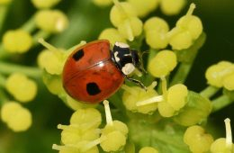

#### [Two-spot Ladybird](https://www.buglife.org.uk/bugs/bug-directory/two-spot-ladybird/)

Adalia bipunctata

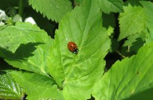

#### [Seven-spot Ladybird](https://www.buglife.org.uk/bugs/bug-directory/seven-spot-ladybird/)

Coccinella septempunctata